# GoFundMe — Backers

```r
library(tidyverse)
library(glmmTMB)
library(gridExtra)
library(glue) # for pretty printing
library(tictoc) # for cell/function profiling
```

## GoFundMe Analysis of Backers

```r
projects = read.csv("../../data/processed/gofundme_projects_clean.csv")
projects$month = factor(projects$month)
projects$day_of_week = factor(projects$day_of_week)
```

In total, we have N=5223 IID samples to work with.

Removed all random variabes except year because they didn’t help explain any variance in the data beyond what the residuals could capture. Year is a reasonable random effect as well (see Variance Components, Searle et al 2006)

Nesting and Chi2 differences: https://www.psychologie.uzh.ch/dam/jcr:ffffffff-b371-2797-0000-00000fda8f29/chisquare_diff_en.pdf

# Backers

```r
upper_limit = quantile(projects$backers, 0.995)
nrow(projects[projects$backers > upper_limit, ])
```

```
## [1] 27
```

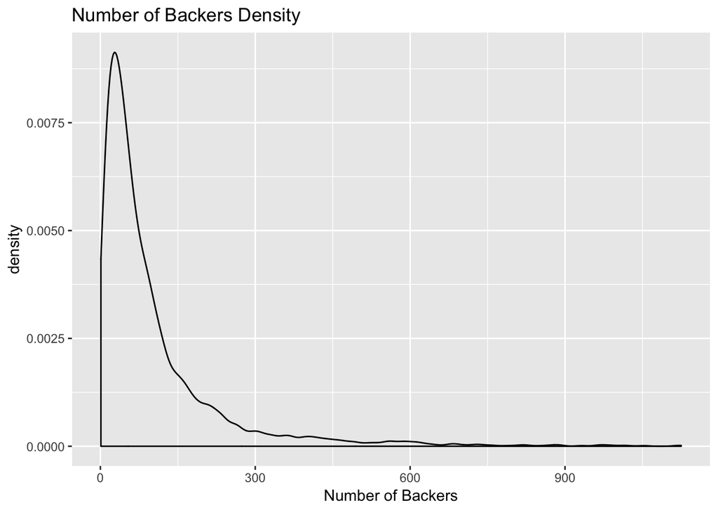

```r
projects.trunc = projects[projects$backers < upper_limit, ]

ggplot() + labs(x="Number of Backers", title="Number of Backers Density") +
  geom_density(aes(projects$backers[projects$backers < upper_limit]))
```

Run a quick data dispersion test (see Rice 1995):

```r
s = na.omit(projects.trunc)
pchisq(2 * sum(projects.trunc$backers * log(projects.trunc$backers / mean(projects.trunc$backers))), length(projects.trunc$backers) - 1, lower.tail = F)
```

```
## [1] 0
```

H0: The data are fit well by a Poisson Distribution H1: Poisson fails to fit the data well

The Poisson distribution obviously does not fit the data well since p approx 0. Let’s use a NegBin instead, which can account for differences in the mean and variance.

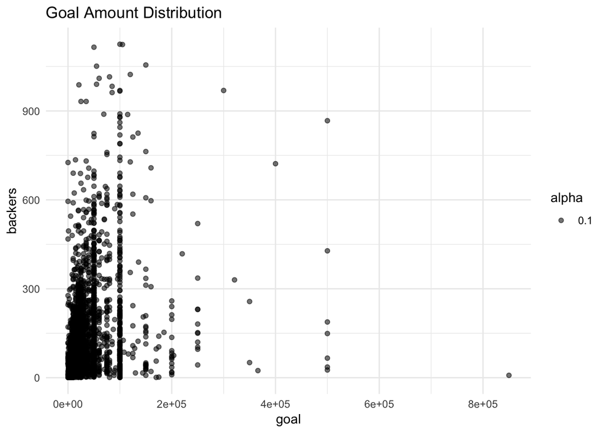

```r
projects.trunc %>%
  ggplot(aes(goal, backers)) + labs(title="Goal Amount Distribution") +
  geom_point(aes(alpha=0.1)) +
  theme_minimal()
```

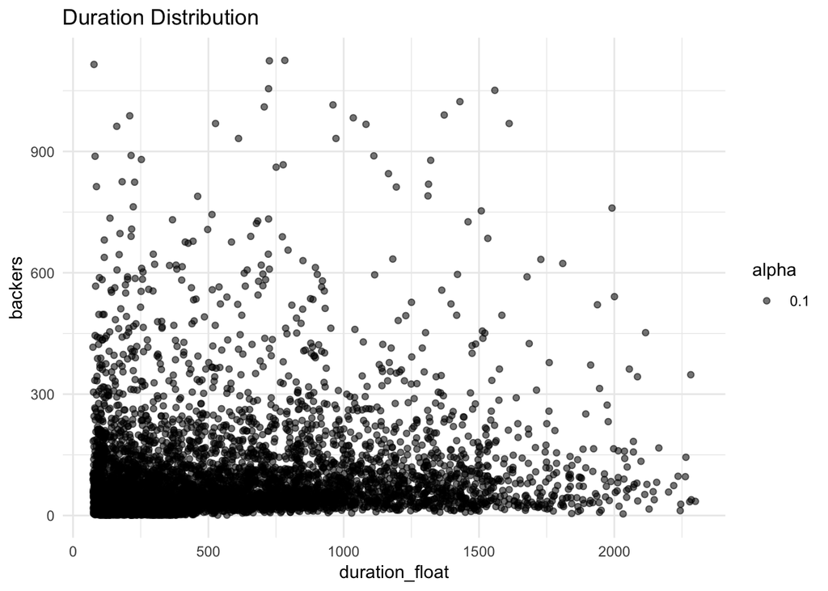

```r
projects.trunc %>%
  ggplot(aes(duration_float, backers)) + labs(title="Duration Distribution") +
  geom_point(aes(alpha=0.1)) +
  theme_minimal()
```

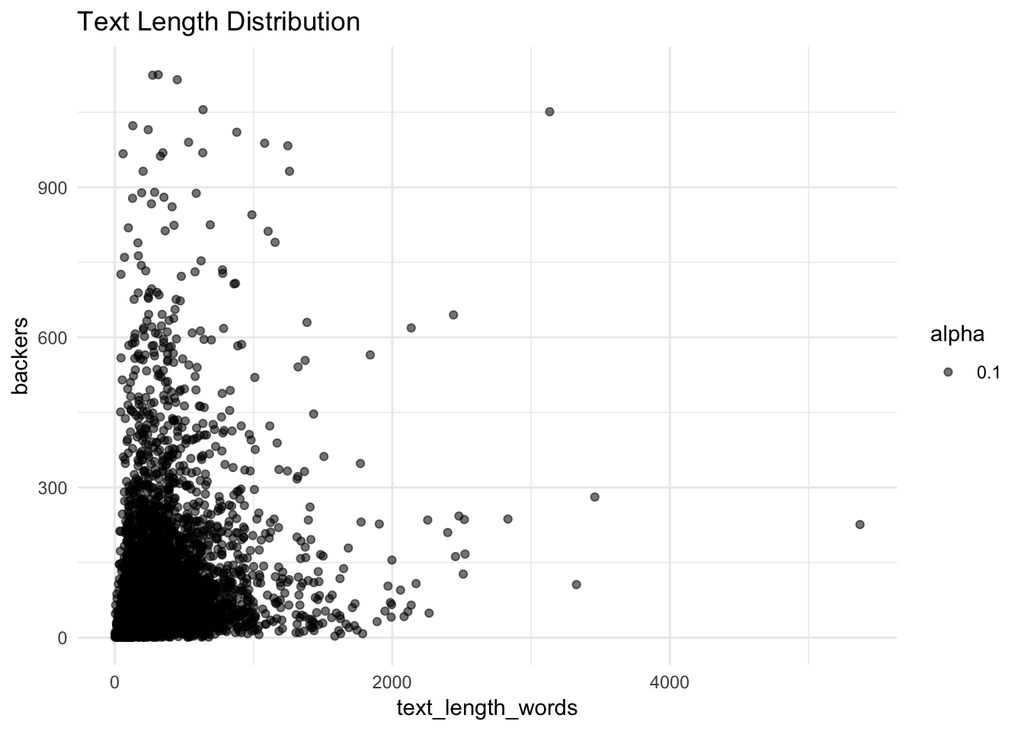

```r
projects.trunc %>%
  ggplot(aes(text_length_words, backers)) + labs(title="Text Length Distribution") +
  geom_point(aes(alpha=0.1)) +
  theme_minimal()
```

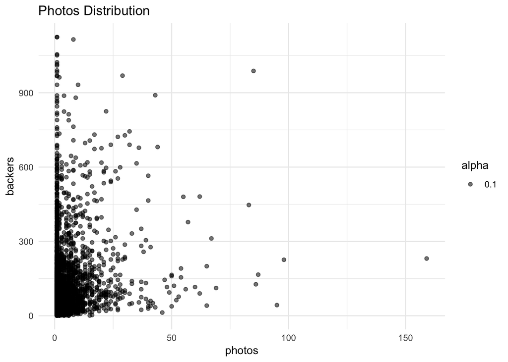

```r
projects.trunc %>%
  ggplot(aes(photos, backers)) + labs(title="Photos Distribution") +
  geom_point(aes(alpha=0.1)) +
  theme_minimal()
```

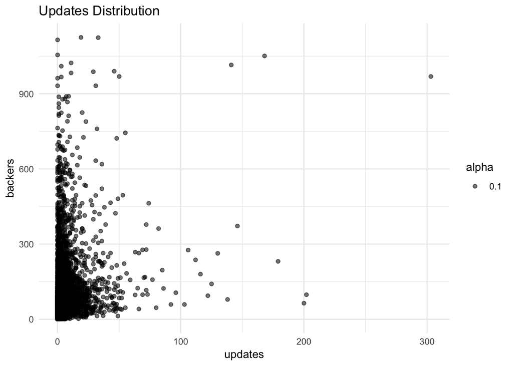

```r
projects.trunc %>%
  ggplot(aes(updates, backers)) + labs(title="Updates Distribution") +
  geom_point(aes(alpha=0.1)) +
  theme_minimal()
```

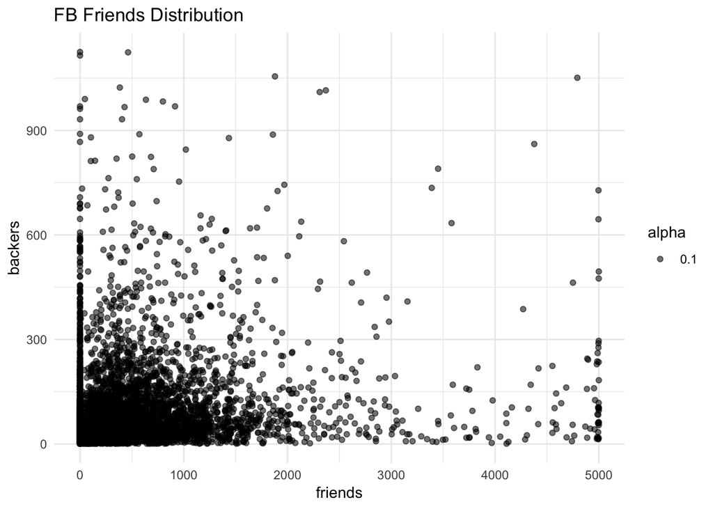

```r
projects.trunc %>%
  ggplot(aes(friends, backers)) + labs(title="FB Friends Distribution") +
  geom_point(aes(alpha=0.1)) +
  theme_minimal()
```

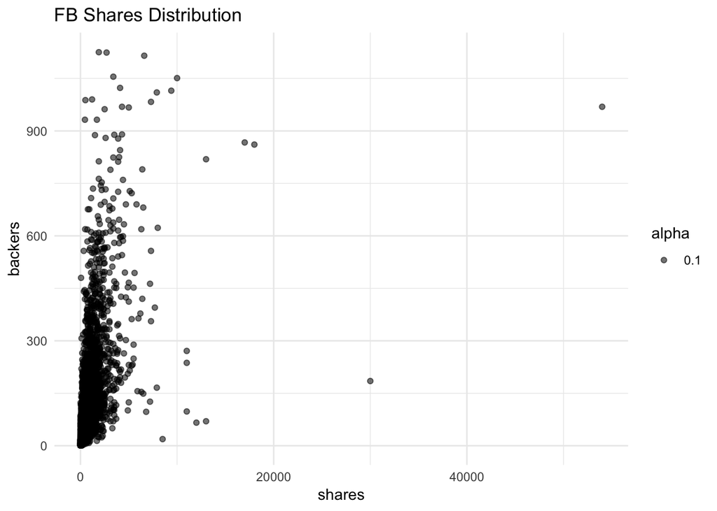

```r
projects.trunc %>%
  ggplot(aes(shares, backers)) + labs(title="FB Shares Distribution") +
  geom_point(aes(alpha=0.1)) +
  theme_minimal()
```

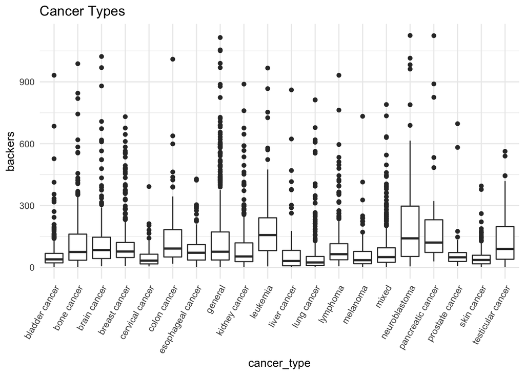

```r
projects.trunc %>%
  ggplot(aes(cancer_type, backers)) + labs(title="Cancer Types") +
  geom_boxplot() +
  theme_minimal() +
  theme(axis.text.x=element_text(angle = 60, hjust=1))
```

Establish the base formula to build models off of:

```r
base.formula = backers ~ shares_sc + friends_sc + updates_sc + photos_sc + goal_sc + text_length_words_sc + duration_float_sc + cancer_type + month + day_of_week + (1|year)
```

Create a helper function to easily compare two models and pretty print the output:

```r
compare = function(model.old, model.new, key, multiplier=1.0) {
  a = anova(model.old, model.new)
  p = a$`Pr(>Chisq)`[2]
  print(glue("Variable: {key}"))
  print(glue("DF diff: {a$`Chi Df`[2]}\t New AIC: {round(a$AIC[2], 1)}\t\t Chisq: {round(a$Chisq[2],1)}\t P(>chisq) = {round(p,4)} {if (p < 0.05) '(significant)' else ''})"))
  effect = as.numeric(summary(mod)$coefficients$cond[key, ])
  print(glue("beta: {round(effect[1],4)} (+/- {round(effect[2],3)})\t stat: {round(effect[3], 2)} => P(>|z|) = {round(effect[4], 4)}"))
  print(glue("rate ratio: {round((exp(effect[1]*multiplier) - 1)*100, 1)}% ({round((exp((effect[1] - effect[2])*multiplier) - 1)*100, 1)}% to {round((exp((effect[1] + effect[2])*multiplier) - 1)*100, 1)}%)"))
  print(glue(""))
}
```

https://stats.stackexchange.com/questions/96972/how-to-interpret-parameters-in-glm-with-family-gamma

Key to interpretation is the log link used here

To put the results from the continuous predictors on interpretable scales, we use a multiplier within the exponent (see `factor` in `compare()`). For example, if the multiplier is 1, this leads to: for a one unit increase in this predictor, we see an *x*-fold increase in the DV.

```r
p = function(var, scl=1, digits=6, mult=1.00, mask=T) {
  mu = mean(projects[mask, var])
  sd = sd(projects[mask, var])
  print(glue("Var: {var}\t Mean: {round(mu,digits)*scl}\t SD: {round(sd,digits)*scl}\t Scale (x{round(mult, 2)}): {paste(round(mult*sd + mu, digits)*scl)}"))
}
p("journey_salience", scl = 1000, digits = 5, mult = 0.6)
```

```
## Var: journey_salience     Mean: 0.52  SD: 1.68    Scale (x0.6): 1.53
```

```r
p("battle_salience", scl = 1000, digits = 5, mult = 0.16)
```

```
## Var: battle_salience  Mean: 3.87  SD: 6.27    Scale (x0.16): 4.87
```

```r
p("journey_prod", digits = 4, mask = projects$journey_metaphor > 0)
```

```
## Var: journey_prod     Mean: 1.5567    SD: 1.0602  Scale (x1): 2.6169
```

```r
p("battle_prod", digits = 4, mask = projects$battle_metaphor > 0)
```

```
## Var: battle_prod  Mean: 3.4581    SD: 3.0339  Scale (x1): 6.492
```

```r
p("first_instantiation", digits = 4, mask = projects$journey_metaphor > 0, mult = 1.6)
```

```
## Var: first_instantiation  Mean: 0.3943    SD: 0.3191  Scale (x1.6): 0.9049
```

```r
p("first_instantiation", digits = 4, mask = projects$battle_metaphor > 0, mult = 1.6)
```

```
## Var: first_instantiation  Mean: 0.3952    SD: 0.3111  Scale (x1.6): 0.8929
```

It might be the case that a quasi-Poisson model fits better, see: https://digitalcommons.unl.edu/cgi/viewcontent.cgi?article=1141&context=usdeptcommercepub

Inherently, the number of backers must be > 0, thus we model using a truncated NegBin fit.

The coefficients of each model can be exponentiated to get the Incident Rate Ratio.

An example rationalization would look like: *Projects with any metaphor are expected to have 5.0% more donors than projects with no metaphors at all, with other predictor values remaining constant.*

## Any Metaphor

Examine: does having any instance of metaphor influence backers?

Null: having any metaphor is not significantly different from having no metaphor

```r
backers.mod.base = glmmTMB(base.formula, data = projects.trunc, family = "truncated_nbinom2")
# drop1(backers.mod.base, test="Chisq")
```

```r
f = update(base.formula,  ~ . - day_of_week)
# drop1(glmmTMB(f, data = projects.trunc, family = "truncated_nbinom2"), test="Chisq")
```

```r
f = update(f,  ~ . - friends_sc)
# drop1(glmmTMB(f, data = projects.trunc, family = "truncated_nbinom2"), test="Chisq")
```

```r
f = update(f,  ~ . - month)
# drop1(glmmTMB(f, data = projects.trunc, family = "truncated_nbinom2"), test="Chisq")
```

```r
backers.mod = glmmTMB(f, data = projects.trunc, family = "truncated_nbinom2")
# summary(backers.mod)
```

### Results

```r
mod = glmmTMB(update(f,  ~ . + any_metaphor), data = projects.trunc, family = "truncated_nbinom2")
compare(backers.mod, mod, "any_metaphorTRUE")
```

```
## Variable: any_metaphorTRUE
## DF diff: 1    New AIC: 55190.2        Chisq: 34.8     P(>chisq) = 0 (significant))
## beta: 0.1358 (+/- 0.023)  stat: 5.92 => P(>|z|) = 0
## rate ratio: 14.5% (12% to 17.2%)
```

```r
# mod = glmmTMB(update(base.formula,  ~ . + any_metaphor), data = projects.trunc, family = "truncated_nbinom2")
# compare(backers.mod.base, mod, "any_metaphorTRUE")
```

## Both Metaphors

Examine: does having both metaphor families present influence backers?

Null: having both metaphor families is not significantly different from having no metaphor

```r
projects.trunc.both = projects.trunc[(1-projects.trunc$any_metaphor) | projects.trunc$both_metaphor, ] # only projects with both or none
```

N = 2788

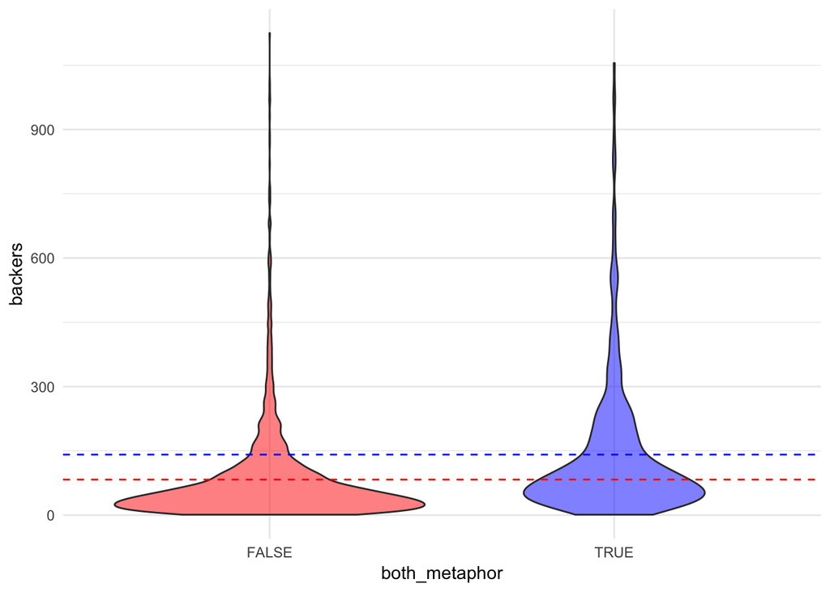

```r
projects.trunc.both %>%
  ggplot() + theme_minimal() +
  geom_violin(aes(both_metaphor, backers, fill=both_metaphor)) +
  scale_fill_manual(values = c("FALSE" = alpha("red", 0.5), "TRUE" = alpha("blue", 0.5)), guide=F) +
  geom_hline(yintercept = mean(projects.trunc.both[projects.trunc.both$both_metaphor == F, ]$backers), lty=2, color="red") +
  geom_hline(yintercept = mean(projects.trunc.both[projects.trunc.both$both_metaphor, ]$backers), lty=2, color="blue")
```

Perform model selection to prevent overfitting:

```r
backers.mod.base = glmmTMB(base.formula, data = projects.trunc.both, family = "truncated_nbinom2")
# drop1(backers.mod.base, test="Chisq")
```

```r
f = update(base.formula,  ~ . - day_of_week)
# drop1(glmmTMB(f, data = projects.trunc.both, family = "truncated_nbinom2"), test="Chisq")
```

```r
backers.mod = glmmTMB(f, data = projects.trunc.both, family = "truncated_nbinom2")
# summary(backers.mod)
```

### Results

```r
mod = glmmTMB(update(f,  ~ . + both_metaphor), data = projects.trunc.both, family = "truncated_nbinom2")
compare(backers.mod, mod, "both_metaphorTRUE")
```

```
## Variable: both_metaphorTRUE
## DF diff: 1    New AIC: 28993      Chisq: 6.9  P(>chisq) = 0.0084 (significant))
## beta: 0.1202 (+/- 0.046)  stat: 2.61 => P(>|z|) = 0.009
## rate ratio: 12.8% (7.7% to 18.1%)
```

```r
# mod = glmmTMB(update(base.formula,  ~ . + both_metaphor), data = projects.trunc.both, family = "truncated_nbinom2")
# compare(backers.mod.base, mod, "both_metaphorTRUE")
```

## Some Metaphor

Examine: does having only journey/battle, or dominant journey/battle, influence backers?

Null: having only journey/battle, or dominant journey/battle, is not significantly different from negative

```r
projects.trunc.some = projects.trunc[projects.trunc$any_metaphor, ]
```

N = 2841

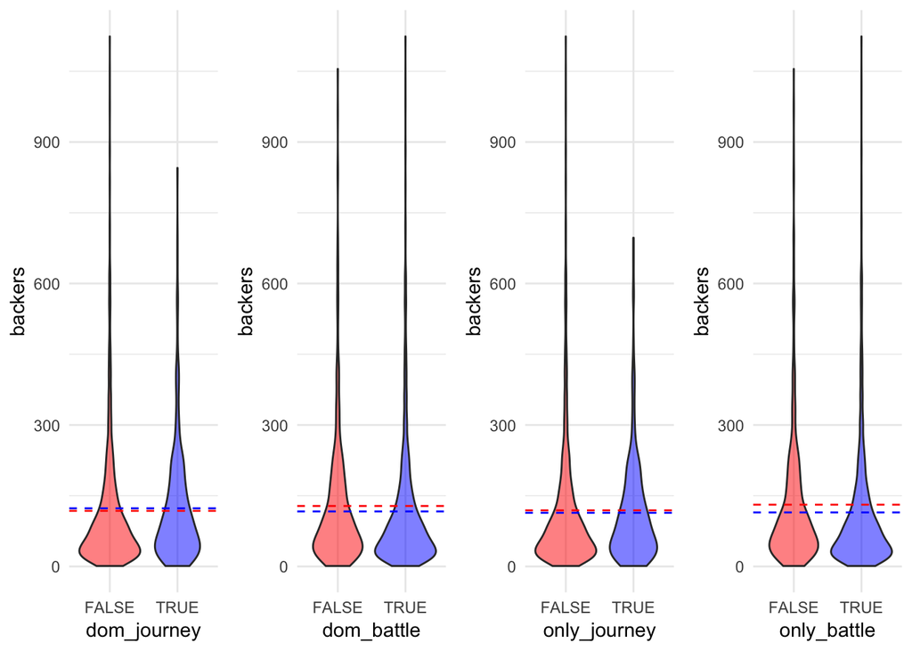

```r
p1 = projects.trunc.some %>%
  ggplot() + theme_minimal() +
  geom_violin(aes(dom_journey, backers, fill=dom_journey)) +
  scale_fill_manual(values = c("FALSE" = alpha("red", 0.5), "TRUE" = alpha("blue", 0.5)), guide=F) +
  geom_hline(yintercept = mean(projects.trunc.some[projects.trunc.some$dom_journey == F, ]$backers), lty=2, color="red") +
  geom_hline(yintercept = mean(projects.trunc.some[projects.trunc.some$dom_journey, ]$backers), lty=2, color="blue")

p2 = projects.trunc.some %>%
  ggplot() + theme_minimal() +
  geom_violin(aes(dom_battle, backers, fill=dom_battle)) +
  scale_fill_manual(values = c("FALSE" = alpha("red", 0.5), "TRUE" = alpha("blue", 0.5)), guide=F) +
  geom_hline(yintercept = mean(projects.trunc.some[projects.trunc.some$dom_battle == F, ]$backers), lty=2, color="red") +
  geom_hline(yintercept = mean(projects.trunc.some[projects.trunc.some$dom_battle, ]$backers), lty=2, color="blue")

p3 = projects.trunc.some %>%
  ggplot() + theme_minimal() +
  geom_violin(aes(only_journey, backers, fill=only_journey)) +
  scale_fill_manual(values = c("FALSE" = alpha("red", 0.5), "TRUE" = alpha("blue", 0.5)), guide=F) +
  geom_hline(yintercept = mean(projects.trunc.some[projects.trunc.some$only_journey == F, ]$backers), lty=2, color="red") +
  geom_hline(yintercept = mean(projects.trunc.some[projects.trunc.some$only_journey, ]$backers), lty=2, color="blue")

p4 = projects.trunc.some %>%
  ggplot() + theme_minimal() +
  geom_violin(aes(only_battle, backers, fill=only_battle)) +
  scale_fill_manual(values = c("FALSE" = alpha("red", 0.5), "TRUE" = alpha("blue", 0.5)), guide=F) +
  geom_hline(yintercept = mean(projects.trunc.some[projects.trunc.some$only_battle == F, ]$backers), lty=2, color="red") +
  geom_hline(yintercept = mean(projects.trunc.some[projects.trunc.some$only_battle, ]$backers), lty=2, color="blue")

grid.arrange(p1, p2, p3, p4, nrow=1)
```

Perform model selection to prevent overfitting:

```r
backers.mod.base = glmmTMB(base.formula, data = projects.trunc.some, family = "truncated_nbinom2")
# drop1(backers.mod.base, test="Chisq")
```

```r
f = update(base.formula,  ~ . - month)
# drop1(glmmTMB(f, data = projects.trunc.some, family = "truncated_nbinom2"), test="Chisq")
```

```r
f = update(f,  ~ . - friends_sc)
# drop1(glmmTMB(f, data = projects.trunc.some, family = "truncated_nbinom2"), test="Chisq")
```

```r
f = update(f,  ~ . - day_of_week)
# drop1(glmmTMB(f, data = projects.trunc.some, family = "truncated_nbinom2"), test="Chisq")
```

```r
f = update(f,  ~ . - duration_float_sc)
# drop1(glmmTMB(f, data = projects.trunc.some, family = "truncated_nbinom2"), test="Chisq")
```

```r
backers.mod = glmmTMB(f, data = projects.trunc.some, family = "truncated_nbinom2")
# summary(backers.mod)
```

### Results

```r
mod = glmmTMB(update(f,  ~ . + dom_journey), data = projects.trunc.some, family = "truncated_nbinom2")
compare(backers.mod, mod, "dom_journeyTRUE")
```

```
## Variable: dom_journeyTRUE
## DF diff: 1    New AIC: 31101.7        Chisq: 1.2  P(>chisq) = 0.266 )
## beta: 0.0505 (+/- 0.046)  stat: 1.11 => P(>|z|) = 0.2688
## rate ratio: 5.2% (0.5% to 10.1%)
```

```r
mod = glmmTMB(update(f,  ~ . + dom_battle), data = projects.trunc.some, family = "truncated_nbinom2")
compare(backers.mod, mod, "dom_battleTRUE")
```

```
## Variable: dom_battleTRUE
## DF diff: 1    New AIC: 31101.1        Chisq: 1.8  P(>chisq) = 0.1744 )
## beta: -0.0529 (+/- 0.039)     stat: -1.35 => P(>|z|) = 0.1767
## rate ratio: -5.2% (-8.8% to -1.4%)
```

```r
mod = glmmTMB(update(f,  ~ . + only_journey), data = projects.trunc.some, family = "truncated_nbinom2")
compare(backers.mod, mod, "only_journeyTRUE")
```

```
## Variable: only_journeyTRUE
## DF diff: 1    New AIC: 31102.9        Chisq: 0    P(>chisq) = 0.8519 )
## beta: 0.0093 (+/- 0.05)   stat: 0.19 => P(>|z|) = 0.8521
## rate ratio: 0.9% (-4% to 6.1%)
```

```r
mod = glmmTMB(update(f,  ~ . + only_battle), data = projects.trunc.some, family = "truncated_nbinom2")
compare(backers.mod, mod, "only_battleTRUE")
```

```
## Variable: only_battleTRUE
## DF diff: 1    New AIC: 31101.7        Chisq: 1.3  P(>chisq) = 0.2581 )
## beta: -0.0382 (+/- 0.034)     stat: -1.13 => P(>|z|) = 0.2594
## rate ratio: -3.7% (-7% to -0.4%)
```

```r
# mod = glmmTMB(update(base.formula,  ~ . + dom_journey), data = projects.trunc.some, family = "truncated_nbinom2")
# compare(backers.mod.base, mod, "dom_journeyTRUE")
#
# mod = glmmTMB(update(base.formula,  ~ . + dom_battle), data = projects.trunc.some, family = "truncated_nbinom2")
# compare(backers.mod.base, mod, "dom_battleTRUE")
#
# mod = glmmTMB(update(base.formula,  ~ . + only_journey), data = projects.trunc.some, family = "truncated_nbinom2")
# compare(backers.mod.base, mod, "only_journeyTRUE")
#
# mod = glmmTMB(update(base.formula,  ~ . + only_battle), data = projects.trunc.some, family = "truncated_nbinom2")
# compare(backers.mod.base, mod, "only_battleTRUE")
```

## Journey

```r
projects.trunc.jor = projects.trunc[projects.trunc$journey_metaphor > 0, ]
```

N = 690

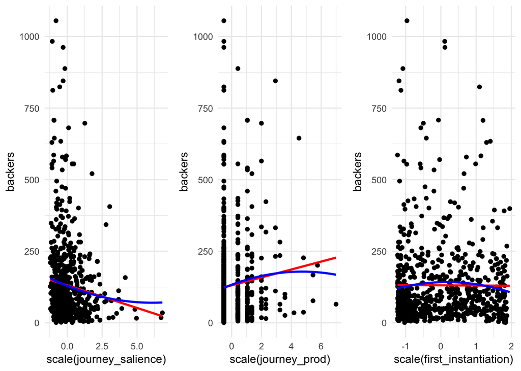

```r
p1 = projects.trunc.jor %>%
  ggplot(aes(scale(journey_salience), backers)) + theme_minimal() +
  geom_point() + geom_smooth(method = "lm", se = F, color="red") + geom_smooth(method = "lm", formula = y ~ poly(x, 2), se = F, color="blue")

p2 = projects.trunc.jor %>%
  ggplot(aes(scale(journey_prod), backers)) + theme_minimal() +
  geom_point() + geom_smooth(method = "lm", se = F, color="red") + geom_smooth(method = "lm", formula = y ~ poly(x, 2), se = F, color="blue")

p3 = projects.trunc.jor %>%
  ggplot(aes(scale(first_instantiation), backers)) + theme_minimal() +
  geom_point() + geom_smooth(method = "lm", se = F, color="red") + geom_smooth(method = "lm", formula = y ~ poly(x, 2), se = F, color="blue")

grid.arrange(p1, p2, p3, nrow=1)
```

Perform model selection to prevent overfitting:

```r
backers.mod.base = glmmTMB(base.formula, data = projects.trunc.jor, family = "truncated_nbinom2")
# drop1(backers.mod.base, test="Chisq")
```

```r
f = update(base.formula,  ~ . - day_of_week)
# drop1(glmmTMB(f, data = projects.trunc.jor, family = "truncated_nbinom2"), test="Chisq")
```

```r
f = update(f,  ~ . - text_length_words_sc)
# drop1(glmmTMB(f, data = projects.trunc.jor, family = "truncated_nbinom2"), test="Chisq")
```

```r
f = update(f,  ~ . - friends_sc)
# drop1(glmmTMB(f, data = projects.trunc.jor, family = "truncated_nbinom2"), test="Chisq")
```

```r
f = update(f,  ~ . - duration_float_sc)
# drop1(glmmTMB(f, data = projects.trunc.jor, family = "truncated_nbinom2"), test="Chisq")
```

```r
f = update(f,  ~ . - month)
# drop1(glmmTMB(f, data = projects.trunc.jor, family = "truncated_nbinom2"), test="Chisq")
```

```r
backers.mod = glmmTMB(f, data = projects.trunc.jor, family = "truncated_nbinom2")
# summary(backers.mod)
```

### Results

```r
mod = glmmTMB(update(f,  ~ . + scale(journey_salience)), data = projects.trunc.jor, family = "truncated_nbinom2")
compare(backers.mod, mod, "scale(journey_salience)", 0.6)
```

```
## Variable: scale(journey_salience)
## DF diff: 1    New AIC: 7737       Chisq: 0.4  P(>chisq) = 0.5113 )
## beta: -0.02 (+/- 0.03)    stat: -0.66 => P(>|z|) = 0.509
## rate ratio: -1.2% (-3% to 0.6%)
```

```r
mod = glmmTMB(update(f,  ~ . + scale(journey_prod)), data = projects.trunc.jor, family = "truncated_nbinom2")
compare(backers.mod, mod, "scale(journey_prod)")
```

```
## Variable: scale(journey_prod)
## DF diff: 1    New AIC: 7735.4         Chisq: 2    P(>chisq) = 0.1548 )
## beta: 0.0406 (+/- 0.029)  stat: 1.4 => P(>|z|) = 0.1609
## rate ratio: 4.1% (1.2% to 7.2%)
```

```r
mod = glmmTMB(update(f,  ~ . + scale(first_instantiation)), data = projects.trunc.jor, family = "truncated_nbinom2")
compare(backers.mod, mod, "scale(first_instantiation)")
```

```
## Variable: scale(first_instantiation)
## DF diff: 1    New AIC: 7737.2         Chisq: 0.3  P(>chisq) = 0.6064 )
## beta: 0.0145 (+/- 0.028)  stat: 0.51 => P(>|z|) = 0.6068
## rate ratio: 1.5% (-1.4% to 4.4%)
```

```r
# mod = glmmTMB(update(base.formula,  ~ . + scale(journey_salience)), data = projects.trunc.jor, family = "truncated_nbinom2")
# compare(backers.mod.base, mod, "scale(journey_salience)", 0.6)
#
# mod = glmmTMB(update(base.formula,  ~ . + scale(journey_prod)), data = projects.trunc.jor, family = "truncated_nbinom2")
# compare(backers.mod.base, mod, "scale(journey_prod)")
#
# mod = glmmTMB(update(base.formula,  ~ . + scale(first_instantiation)), data = projects.trunc.jor, family = "truncated_nbinom2")
# compare(backers.mod.base, mod, "scale(first_instantiation)")
```

## Battle

```r
projects.trunc.bat = projects.trunc[projects.trunc$battle_metaphor > 0, ]
```

N = 2584

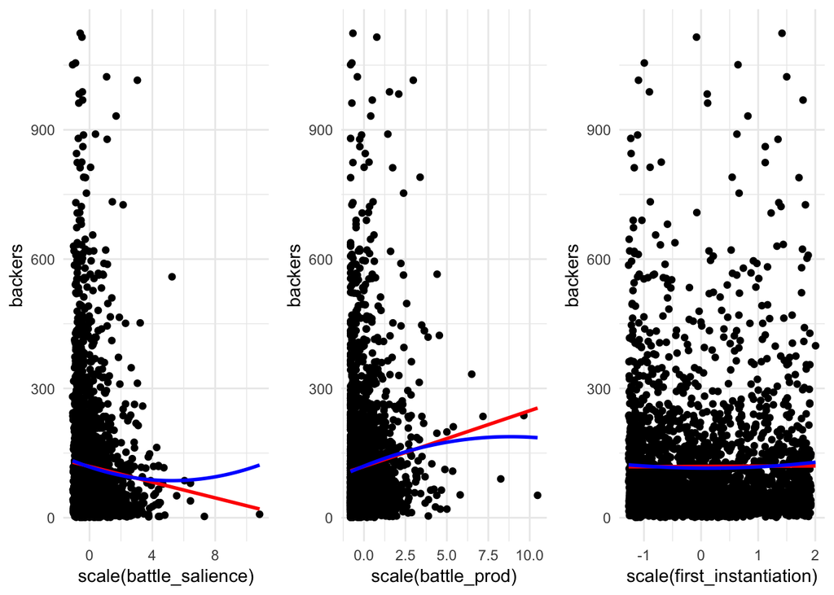

```r
p1 = projects.trunc.bat %>%
  ggplot(aes(scale(battle_salience), backers)) + theme_minimal() +
  geom_point() + geom_smooth(method = "lm", se = F, color="red") + geom_smooth(method = "lm", formula = y ~ poly(x, 2), se = F, color="blue")

p2 = projects.trunc.bat %>%
  ggplot(aes(scale(battle_prod), backers)) + theme_minimal() +
  geom_point() + geom_smooth(method = "lm", se = F, color="red") + geom_smooth(method = "lm", formula = y ~ poly(x, 2), se = F, color="blue")

p3 = projects.trunc.bat %>%
  ggplot(aes(scale(first_instantiation), backers)) + theme_minimal() +
  geom_point() + geom_smooth(method = "lm", se = F, color="red") + geom_smooth(method = "lm", formula = y ~ poly(x, 2), se = F, color="blue")

grid.arrange(p1, p2, p3, nrow=1)
```

Perform model selection to prevent overfitting:

```r
backers.mod.base = glmmTMB(base.formula, data = projects.trunc.bat, family = "truncated_nbinom2")
# drop1(backers.mod.base, test="Chisq")
```

```r
f = update(base.formula,  ~ . - month)
# drop1(glmmTMB(f, data = projects.trunc.bat, family = "truncated_nbinom2"), test="Chisq")
```

```r
f = update(f,  ~ . - friends_sc)
# drop1(glmmTMB(f, data = projects.trunc.bat, family = "truncated_nbinom2"), test="Chisq")
```

```r
f = update(f,  ~ . - day_of_week)
# drop1(glmmTMB(f, data = projects.trunc.bat, family = "truncated_nbinom2"), test="Chisq")
```

```r
f = update(f,  ~ . - duration_float_sc)
# drop1(glmmTMB(f, data = projects.trunc.bat, family = "truncated_nbinom2"), test="Chisq")
```

```r
backers.mod = glmmTMB(f, data = projects.trunc.bat, family = "truncated_nbinom2")
# summary(backers.mod)
```

### Results

```r
mod = glmmTMB(update(f,  ~ . + scale(battle_salience)), data = projects.trunc.bat, family = "truncated_nbinom2")
compare(backers.mod, mod, "scale(battle_salience)", 0.16)
```

```
## Variable: scale(battle_salience)
## DF diff: 1    New AIC: 28306.7        Chisq: 0.1  P(>chisq) = 0.8044 )
## beta: -0.0042 (+/- 0.017)     stat: -0.25 => P(>|z|) = 0.8041
## rate ratio: -0.1% (-0.3% to 0.2%)
```

```r
mod = glmmTMB(update(f,  ~ . + scale(battle_prod)), data = projects.trunc.bat, family = "truncated_nbinom2")
compare(backers.mod, mod, "scale(battle_prod)")
```

```
## Variable: scale(battle_prod)
## DF diff: 1    New AIC: 28302.1        Chisq: 4.7  P(>chisq) = 0.0302 (significant))
## beta: 0.0342 (+/- 0.016)  stat: 2.14 => P(>|z|) = 0.032
## rate ratio: 3.5% (1.8% to 5.1%)
```

```r
mod = glmmTMB(update(f,  ~ . + scale(first_instantiation)), data = projects.trunc.bat, family = "truncated_nbinom2")
compare(backers.mod, mod, "scale(first_instantiation)")
```

```
## Variable: scale(first_instantiation)
## DF diff: 1    New AIC: 28304.3        Chisq: 2.5  P(>chisq) = 0.1136 )
## beta: -0.0242 (+/- 0.015)     stat: -1.59 => P(>|z|) = 0.1129
## rate ratio: -2.4% (-3.9% to -0.9%)
```

```r
# mod = glmmTMB(update(base.formula,  ~ . + scale(battle_salience)), data = projects.trunc.bat, family = "truncated_nbinom2")
# compare(backers.mod.base, mod, "scale(battle_salience)", 0.16)
#
# mod = glmmTMB(update(base.formula,  ~ . + scale(battle_prod)), data = projects.trunc.bat, family = "truncated_nbinom2")
# compare(backers.mod.base, mod, "scale(battle_prod)")
#
# mod = glmmTMB(update(base.formula,  ~ . + scale(first_instantiation)), data = projects.trunc.bat, family = "truncated_nbinom2")
# compare(backers.mod.base, mod, "scale(first_instantiation)")
```